# WiDS : Sentiment Analysis Workshop Part 2

## Zooming to the 1st Dendogram

Thus, after cutting some of the branches of the trees, it gets more clear on the level of the nodes at the leaf where some of the words can be seen are used together.

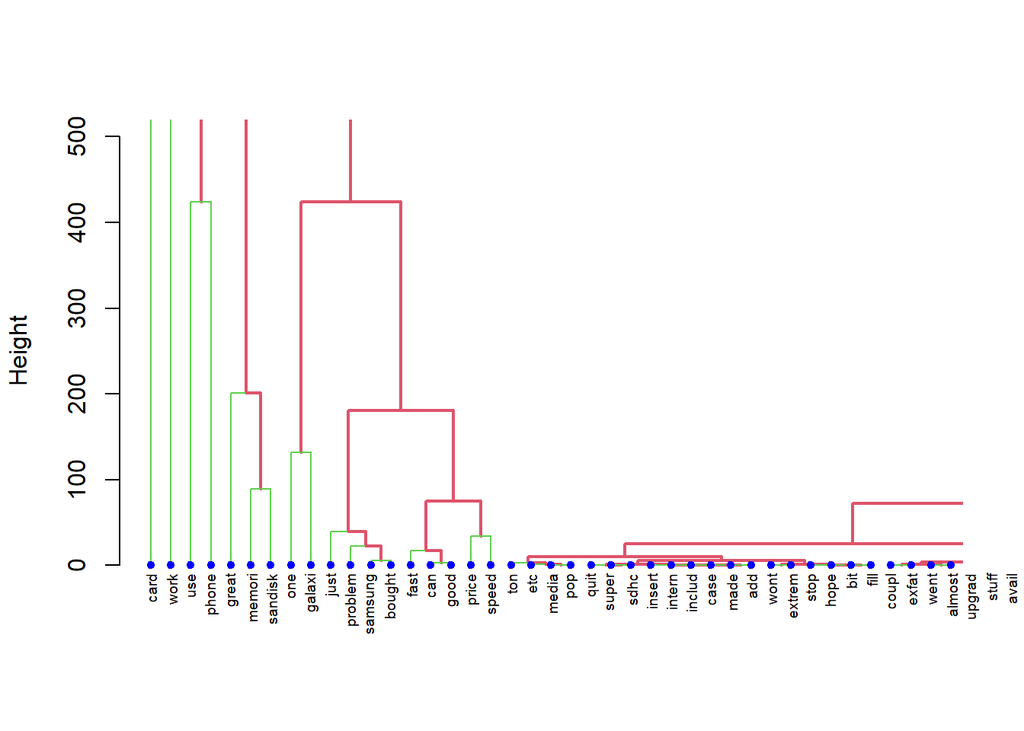

```r
# Zoom in to the first dendogram
nodePar <- list(lab.cex = 0.6, pch = c(NA, 19),
                cex = 0.7, col = "blue")

plot(hcd, xlim = c(1, 40), ylim = c(1, 500), ylab = "Height", nodePar = nodePar,
     edgePar = list(col = 2:3, lwd = 2:1))
```

### Euclidean Distance with Ward

```r
# hc2 <- hclust(d = dist(scale(TDM), method = "euclidean"), method = "ward.D") #Replace method with "single", "average", "ward.D", "ward.D2", "mcquitty", "median", "centroid" to see the change in the Dendrogarm appearence along with change in the heights of the tree
# # Plot a dendrogram
# hcd1 = as.dendrogram(hc2)
# plot(hcd1)
```

### Agglomerative Hierarchical Clustering

Agglomerative HC can be performed with **hclust**. First compute the dissimilarity values with dist and then feed these values into **hclust** and specify the agglomeration method to be used (i.e. “complete”, “average”, “single”, “ward.D”). We can then plot the dendrogram.

The agglomerative coefficient, measures the amount of clustering structure found (values closer to 1 suggest strong clustering structure).

```r
# library(tidyverse)  # data manipulation
# library(cluster)    # clustering algorithms
# library(factoextra) # clustering visualization
# library(dendextend) # for comparing two dendrograms
# library(hclust1d)
#res.agnes <- agnes(TDM, metric = "euclidean", stand = TRUE, method = "complete")

# Agglomerative coefficient
#res.agnes$ac
```

## Plot the Dendrogram

```r
# Plot the tree using pltree()
# plot(as.hclust(res.agnes))
```

### Divisive Hierarchical Clustering

Divisive HC can be performed with the function **diana**. It works in the same way as AGNES but there is no method to provide.

```r
#res.diana <- diana(TDM, metric = "euclidean", stand = FALSE)
#
# # Divise coefficient
#res.diana$dc
#
# Plot the tree using pltree()
# pltree(res.diana, cex = 0.6, hang = -1,
#      main = "Dendrogram of diana")
```

## Emotion Analysis with Library Syuzhet

There are other sentiment libraries such as **syuzhet** with four sentiment dictionaries. It has been developed by the NLP groups at Stanford.

The only difference is instead of just 3 levels of sentiments such as positive, negative and neutral this library also explores classification of emotions on 8 different levels such as trust, surprise, sadness, joy, fear, disgust, anticipation and anger along with two sentiment levels such as positive and negative. It implements the NRC emotion lexicon, **get_nrc_sentiment**.

To read and explore more you can follow the library package here: https://cran.r-project.org/web/packages/syuzhet/vignettes/syuzhet-vignette.html

```r
library(syuzhet)

# Convert to a DTM
#Reviews_DTM <- DocumentTermMatrix(Reviews)

# Terms occurring at least 500 times within the Corpus. Decreasing the number of iteration will increase the number of words within the whole corpus and vice versa
#findFreqTerms(Reviews_DTM, 500)

# Find associations of words that occur at least 600 times with a Correlation of equal to or greater than 0.25
#findAssocs(Reviews_DTM, terms = findFreqTerms(Reviews_DTM, 600), corlimit = 0.25)
```

Convert the DTM into a Vector to proceed to the next steps to extract all the different levels of emotional & sentiment lexicons.